# Project 3 Inferential Statistics - Test a Perceptual Phenomenon - Nitin Ramchand Lalwani

## Analyzing the Stroop Task

The instructions to follow for this project can be found here including the questions to be answered: [Instructions to project](https://docs.google.com/document/u/1/d/1-OkpZLjG_kX9J6LIQ5IltsqMzVWjh36QpnP2RYpVdPU/pub?embedded=True)

Here is a view of the background information of the task:

In a Stroop task, participants are presented with a list of words, with each word displayed in a color of ink. The participant’s task is to say out loud the color of the ink in which the word is printed. The task has two conditions: a congruent words condition, and an incongruent words condition. In the **congruent** words condition, the words being displayed are color words whose names match the colors in which they are printed: for example RED, BLUE. In the **incongruent** words condition, the words displayed are color words whose names do not match the colors in which they are printed: for example PURPLE, ORANGE. In each case, we measure the time it takes to name the ink colors in equally-sized lists. Each participant will go through and record a time from each condition.

**Question**

1) What is our independent variable? What is our dependent variable?

**Answer**

The **dependant variable** in this case is the time taken to name the ink colors.

The **independant variable** is the color of the ink in which the word is printed.

**Question**

2) What is an appropriate set of hypotheses for this task? What kind of statistical test do you expect to perform? Justify your choices.

**Answer**

The null hypothesis $H_{0}$ for this task is:

$H_0 : \mu_c = \mu_I$ There is **no difference** between the mean time in indentifying the **congrugent** words that the mean time in identifying the **incongrugent** words.

**Question**

3) Report some descriptive statistics regarding this dataset. Include at least one measure of central tendency and at least one measure of variability.

**Answer**

```python
import pandas as pd
```

```python
df_stroop = pd.read_csv('stroopdata.csv')
```

```python
df_stroop.head()
```

|  | Congruent | Incongruent |
| --- | --- | --- |
| 0 | 12.079 | 19.278 |
| 1 | 16.791 | 18.741 |
| 2 | 9.564 | 21.214 |
| 3 | 8.630 | 15.687 |
| 4 | 14.669 | 22.803 |

```python
print "Congruent mean =>", df_stroop['Congruent'].mean(), "Incongruent mean =>", df_stroop['Incongruent'].mean()
```

```
Congruent mean => 14.051125 Incongruent mean => 22.0159166667
```

```python
print "Congruent median =>", df_stroop['Congruent'].median(), "Incongruent median =>", df_stroop['Incongruent'].median()
```

```
Congruent median => 14.3565 Incongruent median => 21.0175
```

```python
print "Congruent min =>", round(df_stroop['Congruent'].min(),2), "Incongruent min =>", round(df_stroop['Incongruent'].min(),2)
print "Congruent max =>", round(df_stroop['Congruent'].max(),2), "Incongruent max =>", round(df_stroop['Incongruent'].max(),2)
```

```
Congruent min => 8.63 Incongruent min => 15.69
Congruent max => 22.33 Incongruent max => 35.26
```

```python
print "Congruent variance =>", df_stroop['Congruent'].var(), "Incongruent variance =>", df_stroop['Incongruent'].var()
```

```
Congruent variance => 12.6690290707 Incongruent variance => 23.0117570362
```

```python
print "Congruent standard deviation =>", df_stroop['Congruent'].std(), "Incongruent standard deviation =>", df_stroop['Incongruent'].std()
```

```
Congruent standard deviation => 3.55935795765 Incongruent standard deviation => 4.79705712247
```

**The mean, median, variance and standard deviation for the congruent words are all lower than the ones for the incongruent words. Furthermore, the min and max value of the congruent words are lower than the ones for the incongruent words.**

**Question**

4) Provide one or two visualizations that show the distribution of the sample data. Write one or two sentences noting what you observe about the plot or plots.

**Answer**

```python
import matplotlib.pyplot as plt
%matplotlib inline
import seaborn as sns
sns.set(color_codes=True)
```

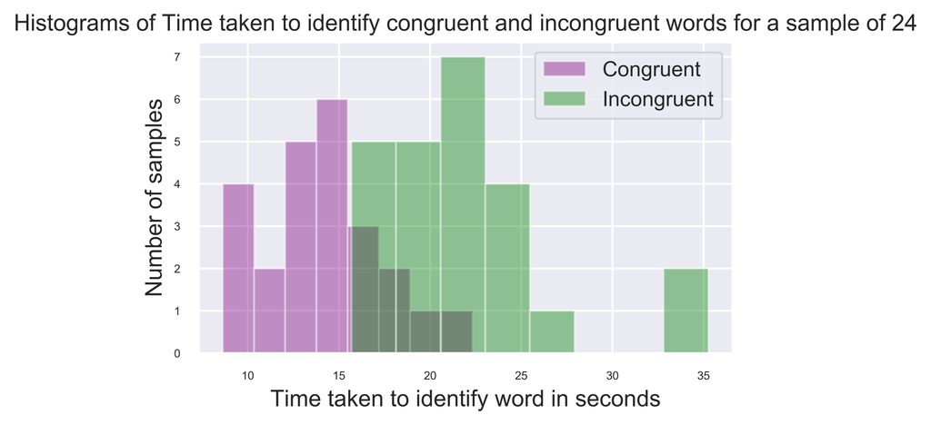

```python
fig, ax = plt.subplots(1, 1, figsize = (5, 3), dpi=1000)
sns.distplot(df_stroop['Congruent'],color='purple', bins=8,label='Congruent', kde=False);
sns.distplot(df_stroop['Incongruent'],color='green', bins=8,label='Incongruent', kde=False);
ax.set_title('Histograms of Time taken to identify congruent and incongruent words for a sample of 24');
plt.legend();
ax.set_ylabel('Number of samples');
ax.set_xlabel('Time taken to identify word in seconds');
ax.tick_params(axis='both', which='major', labelsize=6);
```

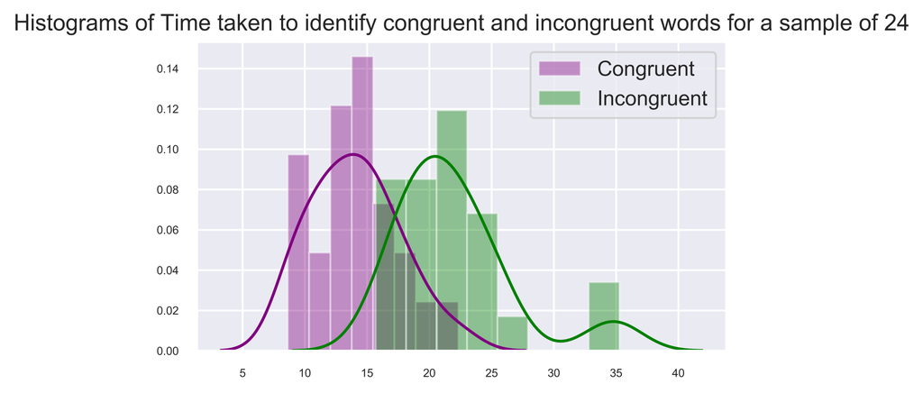

```python
fig, ax = plt.subplots(1, 1, figsize = (5, 3), dpi=1000)
sns.distplot(df_stroop['Congruent'],color='purple', bins=8,label='Congruent');
sns.distplot(df_stroop['Incongruent'],color='green', bins=8,label='Incongruent');
ax.set_title('Histograms of Time taken to identify congruent and incongruent words for a sample of 24');
plt.legend();
ax.set_ylabel('');
ax.set_xlabel('');
ax.tick_params(axis='both', which='major', labelsize=6);
```

**Question**

5) Now, perform the statistical test and report your results. What is your confidence level and your critical statistic value? Do you reject the null hypothesis or fail to reject it? Come to a conclusion in terms of the experiment task. Did the results match up with your expectations?

**Answer**

There are two types of statistical test that can be conducted. Z-test and T-Test

Z-test are useful when we know the population parameters $\mu$ and $\sigma$.

However for this data we have collected in the stroopdata.csv we just have a sample of 24 that we are looking at.

When performing the statistical test, we use the dependant T-test. The reason is that in this case the same subject/person is asked to identify Congruent and Incongruent words and in fact it makes sense when comparing that it is the same person doing so. This results in two values one for congruent words and one for incongruent words.

For performing the ttest for dependant samples on python we use scipy.stats.ttest_rel to check whether the two samples have identical average values and therefore be able to reject or not the null hypothesis.

```python
from scipy import stats
```

```python
stats.ttest_rel(df_stroop['Congruent'], df_stroop['Incongruent'])
```

```
Ttest_relResult(statistic=-8.020706944109957, pvalue=4.103000585711178e-08)
```

Here since the p value results obtainted is much smaller than 5% (0.05) threshold, **we can reject the null hypothesis**. This 5% benchmark is the one used in most papers and examples but however for this test it is also less than 1% so in all cases can be reject the null hypothesis. This 5% or 1% threshold, is known as the **Type I error** which is when the null hypothesis is true but it is rejected. It is like a false positive.

The result of rejecting the null hypothesis makes sense compared to what is intuitive. It makes sense it doesn't take subjects the same time in average to identify Incongruent words than congruent words.